# Subtitle Modality and Cognitive Load: Eye-Tracking Analysis

Authors

2026-10-06

# 1. Packages

```r
library(tidyverse)
library(readxl)
library(mgcv)
library(rstatix)
library(rmcorr)
library(ggplot2)
library(patchwork)
library(knitr)
library(conflicted)

conflict_prefer("filter", "dplyr")
conflict_prefer("lag",    "dplyr")
conflict_prefer("recode", "dplyr")
```

# 2. Data Processing

## 2.1 Aggregate Raw TSV Files

```r
folder_path <- '/Users/nanawu/Downloads/R/Eye-trackingData-raw'
file_list   <- list.files(folder_path, pattern = '\\.tsv$', full.names = TRUE)

cols_needed <- c(
  'Participant', 'Media', 'AOI',
  'Total_duration_of_fixations',
  'Number_of_fixations',
  'Average_pupil_diameter'
)

summary_data <- data.frame()

for (file_path in file_list) {
  raw <- read.csv(file_path, sep = '\t', stringsAsFactors = FALSE)

  raw_filtered <- raw %>%
    filter(
      grepl('SDH$|ST$|LC$', TOI),
      AOI %in% c("SUB", "IMA")
    )

  missing_cols <- setdiff(cols_needed, names(raw_filtered))
  if (length(missing_cols) > 0) {
    warning("Missing in ", basename(file_path), ": ",
            paste(missing_cols, collapse = ", "))
  }

  raw_filtered <- raw_filtered[, intersect(cols_needed, names(raw_filtered))]
  summary_data <- rbind(summary_data, raw_filtered)
}

summary_data <- summary_data %>%
  distinct(Participant, Media, AOI, .keep_all = TRUE)

cat("AOI distribution after aggregation:\n")
```

```
## AOI distribution after aggregation:
```

```r
print(table(summary_data$AOI))
```

```
##
## IMA SUB
## 294 294
```

## 2.2 Clean and Recode

```r
exclude_ids <- c(23, 36, 44, 16)

data <- summary_data %>%
  mutate(across(
    c('Total_duration_of_fixations',
      'Number_of_fixations',
      'Average_pupil_diameter'),
    as.numeric
  )) %>%
  mutate(
    Subtitle_Type = case_when(
      str_detect(Media, "SDH") ~ "SDH",
      str_detect(Media, "LC")  ~ "AC",
      str_detect(Media, "ST")  ~ "SS",
      TRUE ~ NA_character_
    ),
    Modality = case_when(
      str_detect(Media, "^C") ~ "Intralingual",
      str_detect(Media, "^E") ~ "Interlingual",
      TRUE ~ NA_character_
    ),
    Clip        = str_extract(Media, "^[CE][1-3]"),
    Participant = as.factor(Participant)
  ) %>%
  mutate(
    Participant_num = as.integer(str_extract(as.character(Participant), "\\d+"))
  ) %>%
  filter(!Participant_num %in% exclude_ids) %>%
  select(-Participant_num) %>%
  filter(AOI == "IMA" | (!is.na(Subtitle_Type) & !is.na(Modality)))

cat("AOI distribution after cleaning:\n")
```

```
## AOI distribution after cleaning:
```

```r
print(table(data$AOI))
```

```
##
## IMA SUB
## 270 270
```

```r
cat("Participants:", n_distinct(data$Participant), "\n")
```

```
## Participants: 45
```

## 2.3 Merge Word Count

```r
wordcount_data <- read_excel('/Users/nanawu/Downloads/R/Wordcount.xlsx')

data <- left_join(data, wordcount_data, by = 'Media')

sub_unmatched <- data %>%
  filter(AOI == "SUB", is.na(Wordcount)) %>%
  nrow()

if (sub_unmatched > 0) {
  warning(sub_unmatched, " SUB rows unmatched — check Media naming")
} else {
  cat("All SUB rows matched successfully.\n")
}
```

```
## All SUB rows matched successfully.
```

## 2.4 Compute Final Metrics

```r
data <- data %>%
  mutate(
    Total_duration_of_fixations = as.numeric(Total_duration_of_fixations) / 1000
  )

denom <- data %>%
  filter(AOI %in% c("SUB", "IMA")) %>%
  group_by(Participant, Media) %>%
  summarise(
    Fix_SUB_IMA = sum(Total_duration_of_fixations, na.rm = TRUE),
    .groups = "drop"
  )

data_sub <- data %>%
  filter(AOI == "SUB") %>%
  left_join(denom, by = c("Participant", "Media")) %>%
  mutate(
    Prop_reading_time      = Total_duration_of_fixations / Fix_SUB_IMA,
    Mean_fixation_duration = (Total_duration_of_fixations * 1000) / Number_of_fixations,
    Modality      = factor(Modality, levels = c("Intralingual", "Interlingual")),
    Subtitle_Type = factor(Subtitle_Type, levels = c("SS", "AC", "SDH")),
    Clip          = as.factor(Clip),
    Participant   = as.factor(Participant),
    Modality      = relevel(Modality,      ref = "Intralingual"),
    Subtitle_Type = relevel(Subtitle_Type, ref = "SS")
  ) %>%
  select(-Fix_SUB_IMA)

# Participant-normalised pupil diameter (Revision 2, R2-3):
# % change from each participant's median across the six clips
data_sub <- data_sub %>%
  group_by(Participant) %>%
  mutate(
    Pupil_pct = (Average_pupil_diameter - median(Average_pupil_diameter, na.rm = TRUE)) /
                median(Average_pupil_diameter, na.rm = TRUE) * 100
  ) %>%
  ungroup()

write.csv(data_sub, 'data/data_sub_final.csv', row.names = FALSE)
cat("Final dataset rows:", nrow(data_sub), "\n")
```

```
## Final dataset rows: 270
```

## 2.5 Sanity Checks

```r
cat("Rows              :", nrow(data_sub), "\n")
```

```
## Rows              : 270
```

```r
cat("Participants      :", n_distinct(data_sub$Participant), "\n")
```

```
## Participants      : 45
```

```r
cat("Subtitle types    :", paste(levels(data_sub$Subtitle_Type), collapse = ", "), "\n")
```

```
## Subtitle types    : SS, AC, SDH
```

```r
cat("Modalities        :", paste(levels(data_sub$Modality), collapse = ", "), "\n")
```

```
## Modalities        : Intralingual, Interlingual
```

```r
cat("Clips             :", paste(levels(data_sub$Clip), collapse = ", "), "\n")
```

```
## Clips             : C1, C2, C3, E1, E2, E3
```

```r
cat("Prop_reading_time > 1:", sum(data_sub$Prop_reading_time > 1, na.rm = TRUE), "\n")
```

```
## Prop_reading_time > 1: 0
```

```r
cat("Prop_reading_time range:",
    paste(round(range(data_sub$Prop_reading_time, na.rm = TRUE), 3),
          collapse = " - "), "\n")
```

```
## Prop_reading_time range: 0.029 - 0.907
```

## 2.6 Collinearity Check

```r
cor_matrix <- cor(
  data_sub[, c("Total_duration_of_fixations",
               "Mean_fixation_duration",
               "Number_of_fixations")],
  use = "complete.obs"
)
cat("Pairwise correlations among fixation metrics:\n")
```

```
## Pairwise correlations among fixation metrics:
```

```r
print(round(cor_matrix, 3))
```

```
##                             Total_duration_of_fixations Mean_fixation_duration
## Total_duration_of_fixations                       1.000                  0.669
## Mean_fixation_duration                            0.669                  1.000
## Number_of_fixations                               0.781                  0.124
##                             Number_of_fixations
## Total_duration_of_fixations               0.781
## Mean_fixation_duration                    0.124
## Number_of_fixations                       1.000
```

```r
cat("\nNote: Mean_fixation_duration x Number_of_fixations r =",
    round(cor_matrix["Mean_fixation_duration", "Number_of_fixations"], 3),
    "— negligible, confirming distinct theoretical constructs.\n")
```

```
##
## Note: Mean_fixation_duration x Number_of_fixations r = 0.124 — negligible, confirming distinct theoretical constructs.
```

```r
cat("Each metric enters a separate GAM; no within-model collinearity arises.\n")
```

```
## Each metric enters a separate GAM; no within-model collinearity arises.
```

# 3. Descriptive Statistics

```r
eye_tracking_measures <- c(
  "Mean_fixation_duration",
  "Number_of_fixations",
  "Prop_reading_time",
  "Pupil_pct"
)

measure_labels <- c(
  "Mean_fixation_duration" = "Mean Fixation Duration (ms)",
  "Number_of_fixations"    = "Number of Fixations",
  "Prop_reading_time"      = "Proportional Reading Time",
  "Pupil_pct"              = "Pupil Diameter (% change from participant median)"
)
```

```r
desc_stats <- data_sub %>%
  group_by(Modality, Subtitle_Type) %>%
  summarise(
    across(
      all_of(eye_tracking_measures),
      list(M = ~ round(mean(., na.rm = TRUE), 2),
           SD = ~ round(sd(.,   na.rm = TRUE), 2)),
      .names = "{.col}__{.fn}"
    ),
    .groups = "drop"
  )

kable(desc_stats,
      caption = "Table 5. Means and Standard Deviations of Eye-Tracking Measures
                 by Modality and Subtitle Type")
```

Table 5. Means and Standard Deviations of Eye-Tracking Measures by Modality and Subtitle Type

| Modality | Subtitle_Type | Mean_fixation_duration__M | Mean_fixation_duration__SD | Number_of_fixations__M | Number_of_fixations__SD | Prop_reading_time__M | Prop_reading_time__SD | Pupil_pct__M | Pupil_pct__SD |
| --- | --- | --- | --- | --- | --- | --- | --- | --- | --- |
| Intralingual | SS | 257.54 | 102.24 | 325.71 | 150.72 | 0.38 | 0.17 | -2.49 | 6.04 |
| Intralingual | AC | 266.73 | 121.78 | 266.96 | 157.77 | 0.31 | 0.19 | -1.48 | 5.40 |
| Intralingual | SDH | 239.84 | 80.37 | 370.09 | 185.10 | 0.39 | 0.17 | -2.71 | 4.43 |
| Interlingual | SS | 229.08 | 78.53 | 251.64 | 112.60 | 0.30 | 0.16 | 2.06 | 4.34 |
| Interlingual | AC | 230.55 | 78.87 | 418.82 | 126.65 | 0.48 | 0.12 | 3.93 | 4.88 |
| Interlingual | SDH | 236.05 | 83.33 | 295.18 | 116.89 | 0.35 | 0.12 | 1.50 | 5.07 |

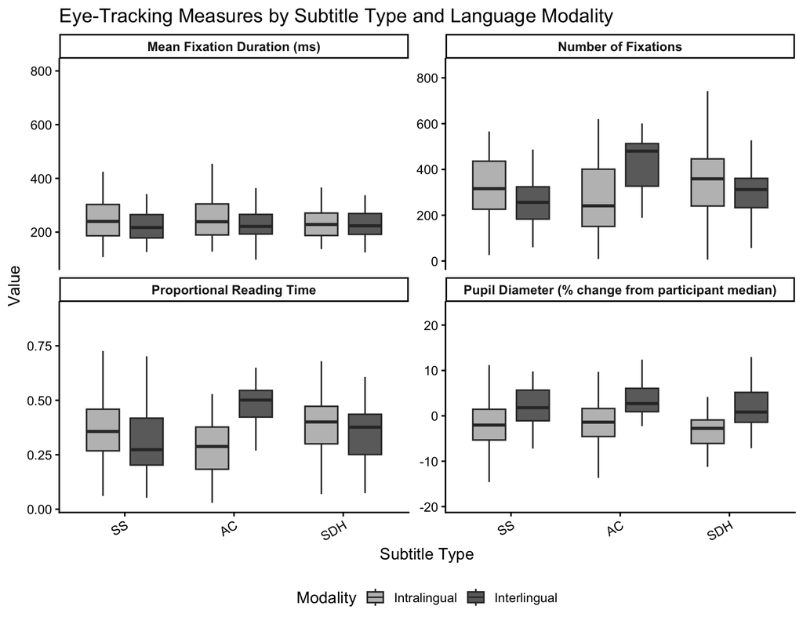

```r
data_long <- data_sub %>%
  select(Modality, Subtitle_Type, all_of(eye_tracking_measures)) %>%
  pivot_longer(
    cols      = all_of(eye_tracking_measures),
    names_to  = "Metric",
    values_to = "Value"
  ) %>%
  mutate(
    Metric        = dplyr::recode(Metric, !!!measure_labels),
    Subtitle_Type = factor(Subtitle_Type, levels = c("SS", "AC", "SDH")),
    Modality      = factor(Modality, levels = c("Intralingual", "Interlingual"))
  )

ggplot(data_long,
       aes(x = Subtitle_Type, y = Value, fill = Modality)) +
  geom_boxplot(
    position      = position_dodge(width = 0.8),
    width         = 0.6,
    outlier.shape = NA,
    alpha         = 0.85
  ) +
  facet_wrap(~ Metric, scales = "free_y", ncol = 2) +
  scale_fill_manual(
    values = c("Intralingual" = "grey70", "Interlingual" = "grey30")
  ) +
  labs(
    title = "Eye-Tracking Measures by Subtitle Type and Language Modality",
    x     = "Subtitle Type", y = "Value", fill = "Modality"
  ) +
  theme_classic(base_size = 13) +
  theme(
    legend.position = "bottom",
    strip.text      = element_text(face = "bold"),
    axis.text.x     = element_text(angle = 30, hjust = 1)
  )
```

# 4. Assumption Checks

```r
library(moments)
library(car)

cat("=== Shapiro-Wilk Normality Tests ===\n")
```

```
## === Shapiro-Wilk Normality Tests ===
```

```r
for (m in eye_tracking_measures) {
  sw <- shapiro.test(data_sub[[m]])
  cat(sprintf("%-30s W = %.4f, p = %.4f %s\n", m, sw$statistic, sw$p.value,
              ifelse(sw$p.value < .05, "* non-normal", "")))
}
```

```
## Mean_fixation_duration         W = 0.8505, p = 0.0000 * non-normal
## Number_of_fixations            W = 0.9884, p = 0.0293 * non-normal
## Prop_reading_time              W = 0.9833, p = 0.0030 * non-normal
## Pupil_pct                      W = 0.9890, p = 0.0379 * non-normal
```

```r
cat("\n=== Levene's Test (Subtitle Type) ===\n")
```

```
##
## === Levene's Test (Subtitle Type) ===
```

```r
for (m in eye_tracking_measures) {
  lt <- car::leveneTest(as.formula(paste(m, "~ Subtitle_Type")), data = data_sub)
  cat(sprintf("%-30s F(%d,%d) = %.3f, p = %.4f %s\n", m,
              lt$Df[1], lt$Df[2], lt$`F value`[1], lt$`Pr(>F)`[1],
              ifelse(lt$`Pr(>F)`[1] < .05, "* heteroscedastic", "")))
}
```

```
## Mean_fixation_duration         F(2,267) = 0.368, p = 0.6925
## Number_of_fixations            F(2,267) = 3.707, p = 0.0258 * heteroscedastic
## Prop_reading_time              F(2,267) = 2.511, p = 0.0831
## Pupil_pct                      F(2,267) = 0.338, p = 0.7134
```

```r
cat("\n=== Skewness and Kurtosis ===\n")
```

```
##
## === Skewness and Kurtosis ===
```

```r
for (m in eye_tracking_measures) {
  x  <- data_sub[[m]][!is.na(data_sub[[m]])]
  sk <- round(skewness(x), 3)
  ku <- round(kurtosis(x), 3)
  cat(sprintf("%-30s skewness = %6.3f, kurtosis = %6.3f\n", m, sk, ku))
}
```

```
## Mean_fixation_duration         skewness =  2.057, kurtosis = 10.389
## Number_of_fixations            skewness =  0.254, kurtosis =  2.849
## Prop_reading_time              skewness =  0.363, kurtosis =  3.283
## Pupil_pct                      skewness =  0.011, kurtosis =  4.008
```

```r
vif_model <- lm(
  Mean_fixation_duration ~ Modality + Subtitle_Type + Wordcount,
  data = data_sub
)
cat("=== Variance Inflation Factors ===\n")
```

```
## === Variance Inflation Factors ===
```

```r
print(car::vif(vif_model))
```

```
##                   GVIF Df GVIF^(1/(2*Df))
## Modality      1.000005  1        1.000002
## Subtitle_Type 1.096546  2        1.023309
## Wordcount     1.096551  1        1.047163
```

# 5. GAM Models

## 5.1 Model Comparison (AIC)

```r
families <- list(
  Mean_fixation_duration  = Gamma(link = "log"),
  Number_of_fixations     = nb(),
  Prop_reading_time       = betar(),
  Pupil_pct               = gaussian()
)

aic_results <- list()

for (measure in eye_tracking_measures) {
  fam <- families[[measure]]
  f   <- function(rhs) as.formula(paste(measure, "~", rhs))

  m1 <- gam(f("1"), family = fam, data = data_sub, method = "REML")
  m2 <- gam(f("Modality + Subtitle_Type"),
            family = fam, data = data_sub, method = "REML")
  m3 <- gam(f("Modality * Subtitle_Type"),
            family = fam, data = data_sub, method = "REML")
  m4 <- gam(f("Modality * Subtitle_Type + s(Wordcount)"),
            family = fam, data = data_sub, method = "REML")
  m5 <- gam(f("Modality * Subtitle_Type + s(Wordcount) + s(Participant, bs='re')"),
            family = fam, data = data_sub, method = "REML")
  m6 <- gam(f("Modality * Subtitle_Type + s(Wordcount) + s(Participant, bs='re') + s(Clip, bs='re')"),
            family = fam, data = data_sub, method = "REML")

  aics           <- AIC(m1, m2, m3, m4, m5, m6)
  aics$Model     <- paste0("M", 1:6)
  aics$Delta_AIC <- round(aics$AIC - min(aics$AIC), 2)
  aics$AIC       <- round(aics$AIC, 2)
  aics$Measure   <- measure
  aic_results[[measure]] <- aics
}

aic_table <- bind_rows(aic_results) %>%
  select(Measure, Model, df, AIC, Delta_AIC)

kable(aic_table,
      caption = "Incremental AIC Model Comparison (ΔAIC < 2 = negligible improvement)")
```

Incremental AIC Model Comparison (ΔAIC < 2 = negligible improvement)

|  | Measure | Model | df | AIC | Delta_AIC |
| --- | --- | --- | --- | --- | --- |
| m1…1 | Mean_fixation_duration | M1 | 2.000000 | 3134.45 | 417.53 |
| m2…2 | Mean_fixation_duration | M2 | 5.000000 | 3134.65 | 417.74 |
| m3…3 | Mean_fixation_duration | M3 | 7.000000 | 3136.85 | 419.93 |
| m4…4 | Mean_fixation_duration | M4 | 9.922845 | 3135.02 | 418.10 |
| m5…5 | Mean_fixation_duration | M5 | 52.301778 | 2718.25 | 1.33 |
| m6…6 | Mean_fixation_duration | M6 | 53.284737 | 2716.92 | 0.00 |
| m1…7 | Number_of_fixations | M1 | 2.000000 | 3515.51 | 238.00 |
| m2…8 | Number_of_fixations | M2 | 5.000000 | 3516.71 | 239.20 |
| m3…9 | Number_of_fixations | M3 | 7.000000 | 3496.61 | 219.10 |
| m4…10 | Number_of_fixations | M4 | 9.503331 | 3460.11 | 182.60 |
| m5…11 | Number_of_fixations | M5 | 50.262080 | 3283.57 | 6.06 |
| m6…12 | Number_of_fixations | M6 | 53.091329 | 3277.51 | 0.00 |
| m1…13 | Prop_reading_time | M1 | 2.000000 | -198.88 | 273.55 |
| m2…14 | Prop_reading_time | M2 | 5.000000 | -197.17 | 275.26 |
| m3…15 | Prop_reading_time | M3 | 7.000000 | -224.48 | 247.95 |
| m4…16 | Prop_reading_time | M4 | 9.225931 | -263.92 | 208.51 |
| m5…17 | Prop_reading_time | M5 | 50.190011 | -447.59 | 24.84 |
| m6…18 | Prop_reading_time | M6 | 51.449840 | -472.43 | 0.00 |
| m1…19 | Pupil_pct | M1 | 2.000000 | 1700.13 | 76.09 |
| m2…20 | Pupil_pct | M2 | 5.000000 | 1646.59 | 22.55 |
| m3…21 | Pupil_pct | M3 | 7.000000 | 1649.89 | 25.86 |
| m4…22 | Pupil_pct | M4 | 10.482081 | 1624.04 | 0.00 |
| m5…23 | Pupil_pct | M5 | 10.483759 | 1624.04 | 0.00 |
| m6…24 | Pupil_pct | M6 | 12.245081 | 1624.27 | 0.23 |

## 5.2 Final Models (M6)

```r
gam_m6 <- list()

for (measure in eye_tracking_measures) {
  fam <- families[[measure]]

  if (measure == "Pupil_pct") {
    f6 <- as.formula(paste(
      measure,
      "~ Modality * Subtitle_Type + Wordcount +",
      "s(Participant, bs='re') + s(Clip, bs='re')"
    ))
  } else {
    f6 <- as.formula(paste(
      measure,
      "~ Modality * Subtitle_Type + s(Wordcount) +",
      "s(Participant, bs='re') + s(Clip, bs='re')"
    ))
  }

  gam_m6[[measure]] <- gam(f6, family = fam, data = data_sub, method = "REML")
}
```

```r
for (measure in eye_tracking_measures) {
  cat("\n\n---\n\n")
  cat("###", gsub("_", " ", measure), "\n\n")
  print(summary(gam_m6[[measure]]))
}
```

### Mean fixation duration

Family: Gamma Link function: log

Formula: Mean_fixation_duration ~ Modality * Subtitle_Type + s(Wordcount) + s(Participant, bs = “re”) + s(Clip, bs = “re”)

Parametric coefficients: Estimate Std. Error t value Pr(>|t|)  
(Intercept) 5.493540 0.053208 103.246 < 2e-16 **ModalityInterlingual -0.107679 0.034977 -3.079 0.00235** Subtitle_TypeAC 0.019403 0.031947 0.607 0.54424  
Subtitle_TypeSDH -0.048965 0.033026 -1.483 0.13960  
ModalityInterlingual:Subtitle_TypeAC -0.009246 0.045692 -0.202 0.83983  
ModalityInterlingual:Subtitle_TypeSDH 0.092156 0.044961 2.050 0.04158  
— Signif. codes: 0 ‘**’ 0.001 ’**’ 0.01 ’’ 0.05 ‘.’ 0.1 ’ ’ 1

Approximate significance of smooth terms: edf Ref.df F p-value  
s(Wordcount) 1.003 1.006 1.821 0.179  
s(Participant) 42.393 44.000 24.533 <2e-16 *** s(Clip) 1.236 4.000 0.466 0.210  
— Signif. codes: 0 ‘**’ 0.001 ’**’ 0.01 ’’ 0.05 ‘.’ 0.1 ’ ’ 1

R-sq.(adj) = 0.785 Deviance explained = 85.5% -REML = 1421.8 Scale est. = 0.022675 n = 270

### Number of fixations

Family: Negative Binomial(9.39) Link function: log

Formula: Number_of_fixations ~ Modality * Subtitle_Type + s(Wordcount) + s(Participant, bs = “re”) + s(Clip, bs = “re”)

Parametric coefficients: Estimate Std. Error z value Pr(>|z|)  
(Intercept) 5.700123 0.094645 60.226 < 2e-16 *ModalityInterlingual -0.218753 0.098054 -2.231 0.02568*  
Subtitle_TypeAC -0.202943 0.071457 -2.840 0.00451 Subtitle_TypeSDH 0.002372 0.078153 0.030 0.97579  
ModalityInterlingual:Subtitle_TypeAC 0.714089 0.103763 6.882 5.91e-12 *** ModalityInterlingual:Subtitle_TypeSDH 0.085155 0.101588 0.838 0.40190  
— Signif. codes: 0 ‘**’ 0.001 ’**’ 0.01 ’’ 0.05 ‘.’ 0.1 ’ ’ 1

Approximate significance of smooth terms: edf Ref.df Chi.sq p-value  
s(Wordcount) 1.847 2.226 21.818 3.52e-05 *s(Participant) 39.999 44.000 425.985 < 2e-16* s(Clip) 2.297 4.000 8.002 0.00987 ** — Signif. codes: 0 ‘**’ 0.001 ’**’ 0.01 ’’ 0.05 ‘.’ 0.1 ’ ’ 1

R-sq.(adj) = 0.712 Deviance explained = 70.6% -REML = 1678.2 Scale est. = 1 n = 270

### Prop reading time

Family: Beta regression(23.242) Link function: logit

Formula: Prop_reading_time ~ Modality * Subtitle_Type + s(Wordcount) + s(Participant, bs = “re”) + s(Clip, bs = “re”)

Parametric coefficients: Estimate Std. Error z value Pr(>|z|)  
(Intercept) -0.48731 0.14090 -3.459 0.000543 ModalityInterlingual -0.31038 0.16489 -1.882 0.059785 .  
Subtitle_TypeAC -0.26677 0.09416 -2.833 0.004608 Subtitle_TypeSDH -0.14323 0.10147 -1.412 0.158079  
ModalityInterlingual:Subtitle_TypeAC 0.94544 0.13602 6.951 3.63e-12 ** ModalityInterlingual:Subtitle_TypeSDH 0.22449 0.13095 1.714 0.086456 .  
— Signif. codes: 0 ‘**’ 0.001 ’**’ 0.01 ’’ 0.05 ‘.’ 0.1 ’ ’ 1

Approximate significance of smooth terms: edf Ref.df Chi.sq p-value  
s(Wordcount) 1.001 1.003 23.50 9.88e-07 *s(Participant) 39.572 44.000 345.39 < 2e-16* s(Clip) 3.080 4.000 21.91 4.48e-05 *** — Signif. codes: 0 ‘**’ 0.001 ’**’ 0.01 ’’ 0.05 ‘.’ 0.1 ’ ’ 1

R-sq.(adj) = 0.712 Deviance explained = 76.9% -REML = -198.86 Scale est. = 1 n = 270

### Pupil pct

Family: gaussian Link function: identity

Formula: Pupil_pct ~ Modality * Subtitle_Type + Wordcount + s(Participant, bs = “re”) + s(Clip, bs = “re”)

Parametric coefficients: Estimate Std. Error t value Pr(>|t|)  
(Intercept) 2.665361 1.630121 1.635 0.103237  
ModalityInterlingual 4.298164 1.141569 3.765 0.000206 Subtitle_TypeAC 0.524303 1.022294 0.513 0.608475  
Subtitle_TypeSDH 0.782069 1.058197 0.739 0.460535  
Wordcount -0.008231 0.002284 -3.604 0.000375 ModalityInterlingual:Subtitle_TypeAC 1.860993 1.462689 1.272 0.204393  
ModalityInterlingual:Subtitle_TypeSDH -0.563711 1.438848 -0.392 0.695540  
— Signif. codes: 0 ‘**’ 0.001 ’**’ 0.01 ’’ 0.05 ‘.’ 0.1 ’ ’ 1

Approximate significance of smooth terms: edf Ref.df F p-value s(Participant) 0.0008773 44 0.000 1.000 s(Clip) 1.4188594 4 0.543 0.198

R-sq.(adj) = 0.261 Deviance explained = 28.2% -REML = 806.97 Scale est. = 23.22 n = 270

## 5.3 Model Diagnostics

```r
for (measure in eye_tracking_measures) {
  cat("\n---", measure, "---\n")
  par(mfrow = c(2, 2))
  gam.check(gam_m6[[measure]])
  par(mfrow = c(1, 1))
}
```

```
##
## --- Mean_fixation_duration ---
```

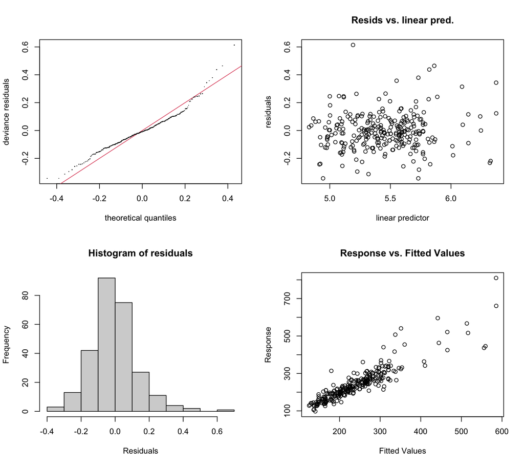

```
##
## Method: REML   Optimizer: outer newton
## full convergence after 5 iterations.
## Gradient range [-0.0003758744,0.0009379442]
## (score 1421.807 & scale 0.02267538).
## Hessian positive definite, eigenvalue range [0.0003289398,136.3272].
## Model rank =  66 / 66
##
## Basis dimension (k) checking results. Low p-value (k-index<1) may
## indicate that k is too low, especially if edf is close to k'.
##
##                   k'   edf k-index p-value
## s(Wordcount)    9.00  1.00    0.98    0.32
## s(Participant) 45.00 42.39      NA      NA
## s(Clip)         6.00  1.24      NA      NA
##
## --- Number_of_fixations ---
```

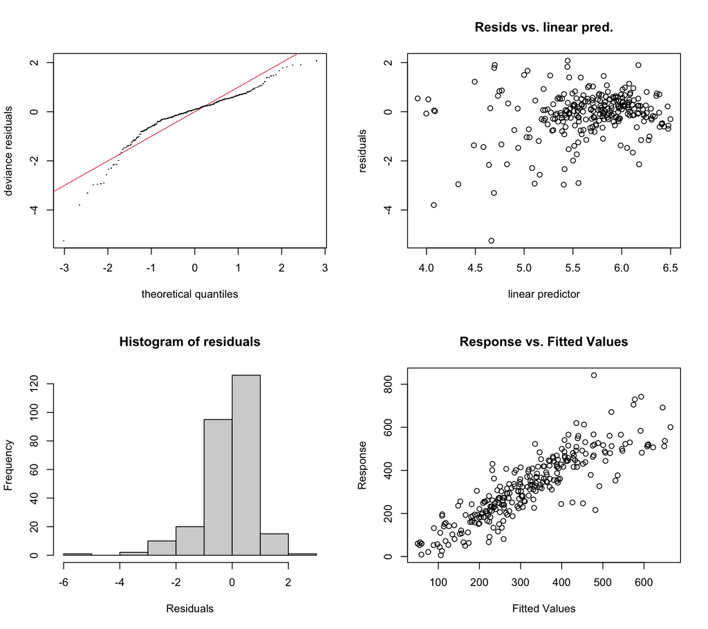

```
##
## Method: REML   Optimizer: outer newton
## full convergence after 5 iterations.
## Gradient range [-2.931144e-06,3.006135e-06]
## (score 1678.184 & scale 1).
## Hessian positive definite, eigenvalue range [0.267273,94.46792].
## Model rank =  66 / 66
##
## Basis dimension (k) checking results. Low p-value (k-index<1) may
## indicate that k is too low, especially if edf is close to k'.
##
##                   k'   edf k-index p-value
## s(Wordcount)    9.00  1.85    1.02    0.69
## s(Participant) 45.00 40.00      NA      NA
## s(Clip)         6.00  2.30      NA      NA
##
## --- Prop_reading_time ---
```

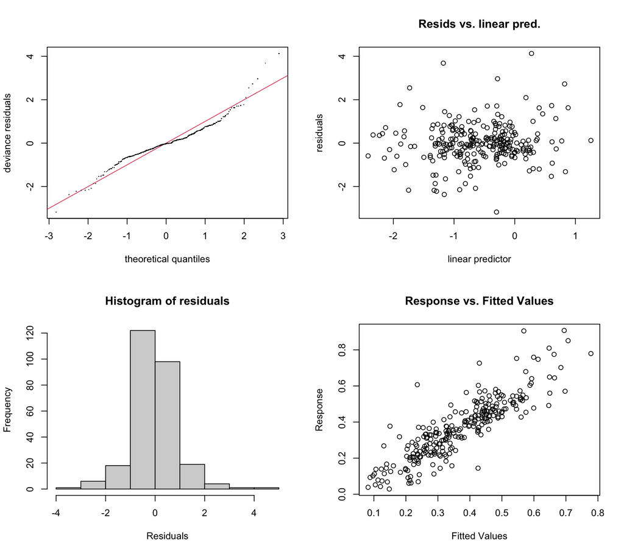

```
##
## Method: REML   Optimizer: outer newton
## full convergence after 7 iterations.
## Gradient range [-0.0003323625,-5.270762e-05]
## (score -198.8614 & scale 1).
## Hessian positive definite, eigenvalue range [5.347589e-05,111.9629].
## Model rank =  66 / 66
##
## Basis dimension (k) checking results. Low p-value (k-index<1) may
## indicate that k is too low, especially if edf is close to k'.
##
##                   k'   edf k-index p-value
## s(Wordcount)    9.00  1.00    1.16    0.98
## s(Participant) 45.00 39.57      NA      NA
## s(Clip)         6.00  3.08      NA      NA
##
## --- Pupil_pct ---
```

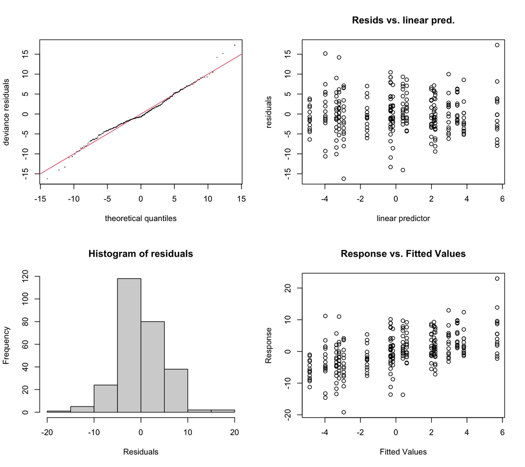

```
##
## Method: REML   Optimizer: outer newton
## full convergence after 12 iterations.
## Gradient range [-0.0002898013,0.0001488385]
## (score 806.9684 & scale 23.21963).
## Hessian positive definite, eigenvalue range [0.0002897983,131.5037].
## Model rank =  58 / 58
##
## Basis dimension (k) checking results. Low p-value (k-index<1) may
## indicate that k is too low, especially if edf is close to k'.
##
##                      k'      edf k-index p-value
## s(Participant) 4.50e+01 8.77e-04      NA      NA
## s(Clip)        6.00e+00 1.42e+00      NA      NA
```

## 5.4 GAM Predicted Plots

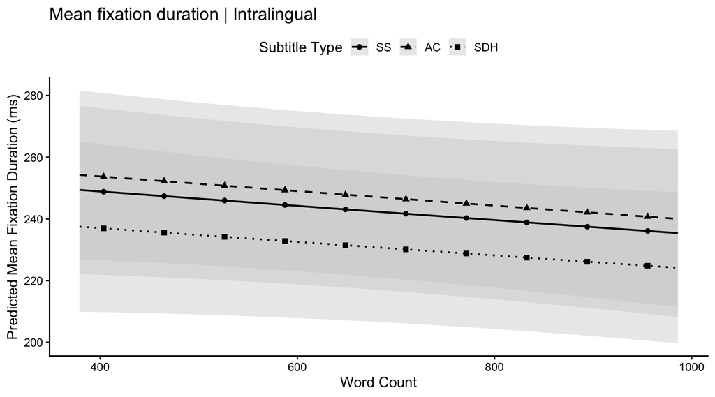

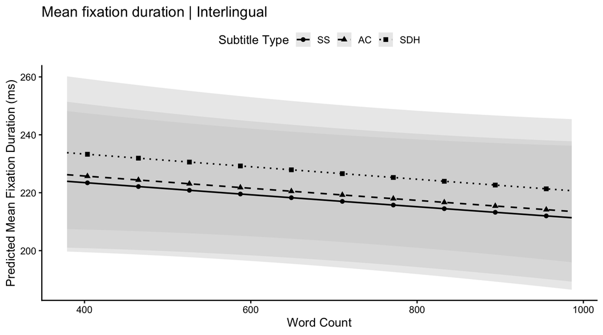

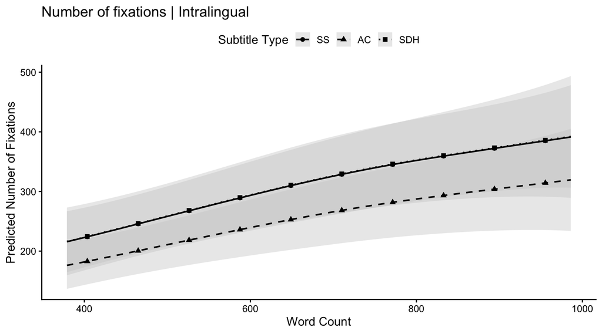

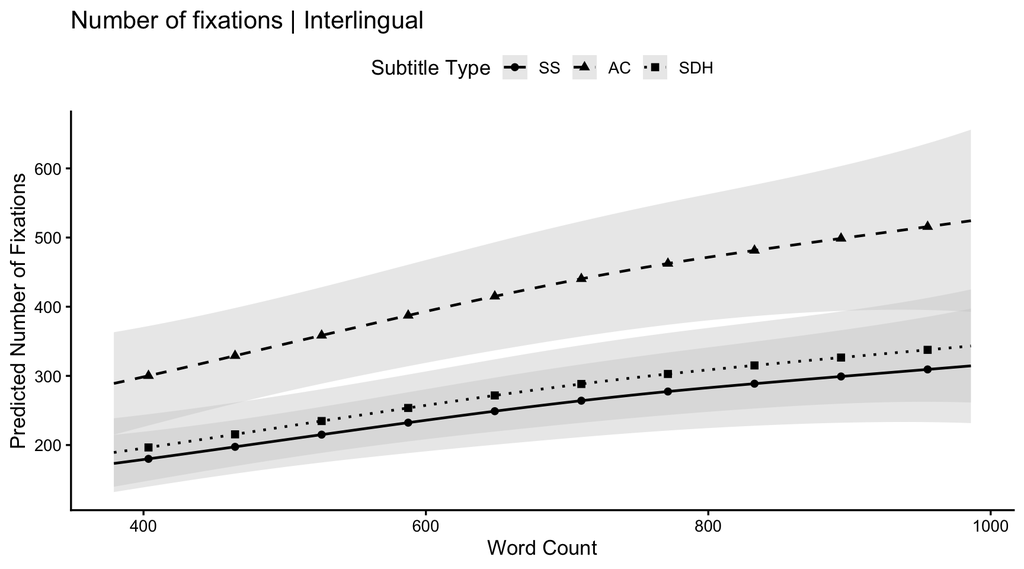

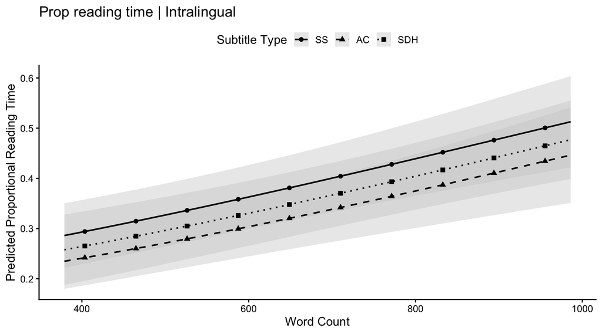

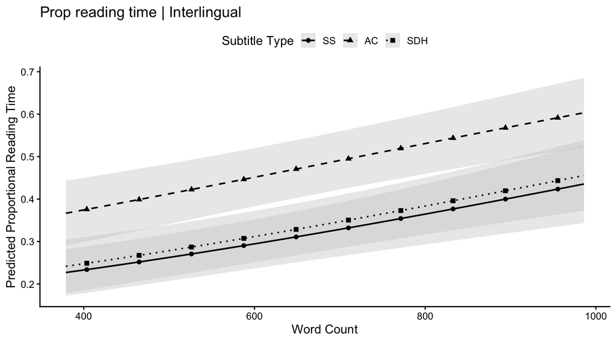

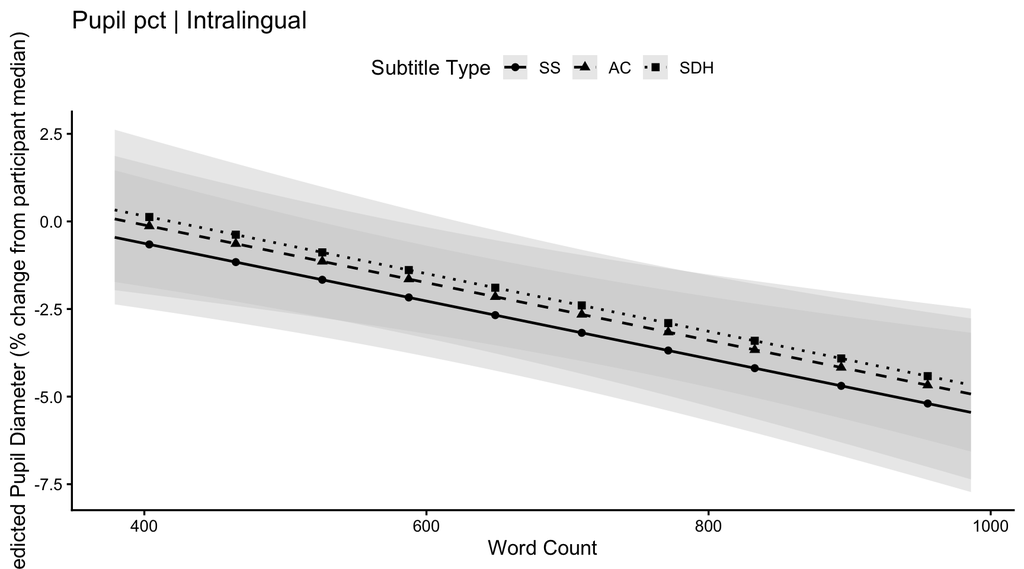

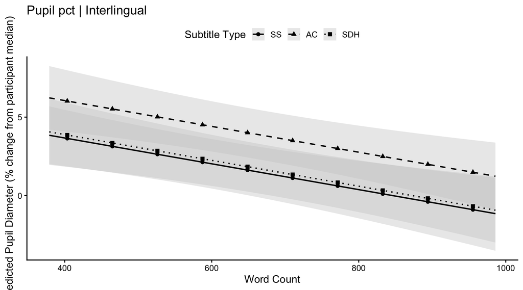

```r
subtitle_type_levels <- c("SS", "AC", "SDH")
type_linetypes       <- c("SS" = 1, "AC" = 2, "SDH" = 3)
type_shapes          <- c("SS" = 16, "AC" = 17, "SDH" = 15)

wc_seq <- seq(
  min(data_sub$Wordcount, na.rm = TRUE),
  max(data_sub$Wordcount, na.rm = TRUE),
  length.out = 100
)

for (measure in eye_tracking_measures) {
  for (modality in c("Intralingual", "Interlingual")) {

    model <- gam_m6[[measure]]

    newdat <- expand.grid(
      Wordcount     = wc_seq,
      Modality      = factor(modality, levels = levels(data_sub$Modality)),
      Subtitle_Type = factor(subtitle_type_levels,
                             levels = levels(data_sub$Subtitle_Type)),
      Participant   = data_sub$Participant[1],
      Clip          = data_sub$Clip[1]
    )

    pred <- predict(model, newdata = newdat, se.fit = TRUE,
                    exclude = c("s(Participant)", "s(Clip)"),
                    type = "response")

    plot_df <- newdat %>%
      mutate(fit   = pred$fit, se = pred$se.fit,
             lower = fit - 1.96 * se, upper = fit + 1.96 * se)

    point_df <- plot_df %>%
      group_by(Subtitle_Type) %>%
      slice(seq(5, n(), by = 10))

    p <- ggplot(plot_df,
                aes(x = Wordcount, y = fit,
                    linetype = Subtitle_Type,
                    shape    = Subtitle_Type,
                    group    = Subtitle_Type)) +
      geom_ribbon(aes(ymin = lower, ymax = upper),
                  fill = "grey80", alpha = 0.4, colour = NA) +
      geom_line(linewidth = 0.8, colour = "black") +
      geom_point(data = point_df, colour = "black", size = 2) +
      scale_linetype_manual(values = type_linetypes) +
      scale_shape_manual(values = type_shapes) +
      labs(
        title    = paste0(gsub("_", " ", measure), " | ", modality),
        x        = "Word Count",
        y        = paste0("Predicted ", measure_labels[measure]),
        linetype = "Subtitle Type", shape = "Subtitle Type"
      ) +
      theme_classic(base_size = 13) +
      theme(legend.position = "top")

    print(p)
  }
}
```

## 5.5 Raw Pupil Diameter Model (for comparison; reported in response letter)

Main analyses use participant-normalised pupil diameter (Pupil_pct). The model below uses raw pupil diameter (mm) with the same specification, as in the previous manuscript version.

```r
data_sub %>%
  group_by(Modality, Subtitle_Type) %>%
  summarise(M  = round(mean(Average_pupil_diameter, na.rm = TRUE), 2),
            SD = round(sd(Average_pupil_diameter,   na.rm = TRUE), 2),
            .groups = "drop") %>%
  kable(caption = "Raw pupil diameter (mm)")
```

Raw pupil diameter (mm)

| Modality | Subtitle_Type | M | SD |
| --- | --- | --- | --- |
| Intralingual | SS | 4.37 | 0.88 |
| Intralingual | AC | 4.41 | 0.80 |
| Intralingual | SDH | 4.36 | 0.82 |
| Interlingual | SS | 4.59 | 0.93 |
| Interlingual | AC | 4.65 | 0.88 |
| Interlingual | SDH | 4.55 | 0.86 |

```r
gam_pupil_raw <- gam(
  Average_pupil_diameter ~ Modality * Subtitle_Type + Wordcount +
    s(Participant, bs = 're') + s(Clip, bs = 're'),
  family = gaussian(), data = data_sub, method = "REML"
)
summary(gam_pupil_raw)
```

```
##
## Family: gaussian
## Link function: identity
##
## Formula:
## Average_pupil_diameter ~ Modality * Subtitle_Type + Wordcount +
##     s(Participant, bs = "re") + s(Clip, bs = "re")
##
## Parametric coefficients:
##                                         Estimate Std. Error t value Pr(>|t|)
## (Intercept)                            4.5972519  0.1449499  31.716  < 2e-16
## ModalityInterlingual                   0.2025763  0.0529948   3.823 0.000172
## Subtitle_TypeAC                        0.0127793  0.0489738   0.261 0.794383
## Subtitle_TypeSDH                       0.0285724  0.0505372   0.565 0.572400
## Wordcount                             -0.0003607  0.0001058  -3.410 0.000774
## ModalityInterlingual:Subtitle_TypeAC   0.0797436  0.0700081   1.139 0.255925
## ModalityInterlingual:Subtitle_TypeSDH -0.0331894  0.0689244  -0.482 0.630619
##
## (Intercept)                           ***
## ModalityInterlingual                  ***
## Subtitle_TypeAC
## Subtitle_TypeSDH
## Wordcount                             ***
## ModalityInterlingual:Subtitle_TypeAC
## ModalityInterlingual:Subtitle_TypeSDH
## ---
## Signif. codes:  0 '***' 0.001 '**' 0.01 '*' 0.05 '.' 0.1 ' ' 1
##
## Approximate significance of smooth terms:
##                   edf Ref.df     F p-value
## s(Participant) 43.439     44 77.46  <2e-16 ***
## s(Clip)         1.125      4  0.42   0.216
## ---
## Signif. codes:  0 '***' 0.001 '**' 0.01 '*' 0.05 '.' 0.1 ' ' 1
##
## R-sq.(adj) =  0.928   Deviance explained = 94.2%
## -REML = 103.61  Scale est. = 0.053305  n = 270
```

# 6. Questionnaire Analysis

## 6.1 Load and Prepare Data

```r
questionnaire_raw <- read_excel('/Users/nanawu/Downloads/R/questionnaire_data.xlsx')
exclude_ids <- c(16, 23, 36, 44)

diff_enj <- questionnaire_raw %>%
  filter(TOI %in% c("ENJ", "ENJ-1", "ENJ1", "ENJ-2", "ENJ2",
                    "SD",  "SD-1",  "SD1")) %>%
  mutate(
    Last_key_press = as.numeric(Last_key_press),
    # Reverse score SD: high score = difficult
    Last_key_press = if_else(
      str_detect(TOI, "SD"),
      8 - Last_key_press,
      Last_key_press
    ),
    Metric = case_when(
      str_detect(TOI, "ENJ") ~ "Enjoyment",
      str_detect(TOI, "SD")  ~ "Self_Reported_Difficulty",
      TRUE ~ NA_character_
    ),
    Subtitle_Type = case_when(
      str_detect(Media, "SDH") ~ "SDH",
      str_detect(Media, "LC")  ~ "AC",
      str_detect(Media, "ST")  ~ "SS",
      TRUE ~ NA_character_
    ),
    Modality = case_when(
      str_detect(Media, "^C") ~ "Intralingual",
      str_detect(Media, "^E") ~ "Interlingual",
      TRUE ~ NA_character_
    ),
    Participant = as.factor(Participant)
  ) %>%
  mutate(Participant_num = as.integer(
    str_extract(as.character(Participant), "\\d+"))) %>%
  filter(!Participant_num %in% exclude_ids) %>%
  select(-Participant_num) %>%
  filter(!is.na(Metric), !is.na(Subtitle_Type), !is.na(Modality)) %>%
  group_by(Participant, Media, Metric, Subtitle_Type, Modality) %>%
  summarise(Score = mean(Last_key_press, na.rm = TRUE), .groups = "drop")

pref_data <- questionnaire_raw %>%
  filter(TOI == "PREF") %>%
  mutate(
    Last_key_press = as.numeric(Last_key_press),
    Preference = case_when(
      Last_key_press == 1 ~ "SS",
      Last_key_press == 2 ~ "SDH",
      Last_key_press == 3 ~ "AC",
      TRUE ~ NA_character_
    ),
    Modality = case_when(
      str_detect(Media, "^C") ~ "Intralingual",
      str_detect(Media, "^E") ~ "Interlingual",
      TRUE ~ NA_character_
    ),
    Participant = as.factor(Participant)
  ) %>%
  mutate(Participant_num = as.integer(
    str_extract(as.character(Participant), "\\d+"))) %>%
  filter(!Participant_num %in% exclude_ids) %>%
  select(-Participant_num) %>%
  filter(!is.na(Preference), !is.na(Modality))

cat("Difficulty/Enjoyment rows:", nrow(diff_enj), "\n")
```

```
## Difficulty/Enjoyment rows: 540
```

```r
cat("Preference rows:", nrow(pref_data), "\n")
```

```
## Preference rows: 90
```

```r
# Verify reverse scoring
cat("\nSD means after reverse scoring (AC should be highest):\n")
```

```
##
## SD means after reverse scoring (AC should be highest):
```

```r
diff_enj %>%
  filter(Metric == "Self_Reported_Difficulty") %>%
  group_by(Subtitle_Type) %>%
  summarise(M = round(mean(Score, na.rm = TRUE), 2)) %>%
  print()
```

```
## # A tibble: 3 × 2
##   Subtitle_Type     M
##   <chr>         <dbl>
## 1 AC             4.09
## 2 SDH            2.9
## 3 SS             2.63
```

## 6.2 Descriptive Statistics

```r
desc_q <- diff_enj %>%
  group_by(Modality, Subtitle_Type, Metric) %>%
  summarise(
    M  = round(mean(Score, na.rm = TRUE), 2),
    SD = round(sd(Score,   na.rm = TRUE), 2),
    .groups = "drop"
  )

kable(desc_q, caption = "Descriptive Statistics: Difficulty and Enjoyment")
```

Descriptive Statistics: Difficulty and Enjoyment

| Modality | Subtitle_Type | Metric | M | SD |
| --- | --- | --- | --- | --- |
| Interlingual | AC | Enjoyment | 3.73 | 1.60 |
| Interlingual | AC | Self_Reported_Difficulty | 4.78 | 1.81 |
| Interlingual | SDH | Enjoyment | 4.18 | 1.33 |
| Interlingual | SDH | Self_Reported_Difficulty | 2.87 | 1.39 |
| Interlingual | SS | Enjoyment | 3.96 | 1.13 |
| Interlingual | SS | Self_Reported_Difficulty | 2.64 | 1.45 |
| Intralingual | AC | Enjoyment | 3.57 | 1.55 |
| Intralingual | AC | Self_Reported_Difficulty | 3.40 | 1.67 |
| Intralingual | SDH | Enjoyment | 4.13 | 1.39 |
| Intralingual | SDH | Self_Reported_Difficulty | 2.93 | 1.75 |
| Intralingual | SS | Enjoyment | 3.69 | 1.18 |
| Intralingual | SS | Self_Reported_Difficulty | 2.62 | 1.40 |

```r
cat("\nPreference counts by Modality:\n")
```

```
##
## Preference counts by Modality:
```

```r
pref_data %>%
  count(Modality, Preference) %>%
  pivot_wider(names_from = Preference, values_from = n, values_fill = 0) %>%
  print()
```

```
## # A tibble: 2 × 4
##   Modality        AC   SDH    SS
##   <chr>        <int> <int> <int>
## 1 Interlingual     3    24    18
## 2 Intralingual     5    25    15
```

## 6.3 Friedman Tests — Subtitle Type Effect

```r
cat("=== Friedman Test: Subtitle Type Effect ===\n\n")
```

```
## === Friedman Test: Subtitle Type Effect ===
```

```r
for (metric in c("Self_Reported_Difficulty", "Enjoyment")) {
  for (mod in c("Intralingual", "Interlingual")) {

    d <- diff_enj %>%
      filter(Metric == metric, Modality == mod) %>%
      group_by(Participant, Subtitle_Type) %>%
      summarise(Score = mean(Score, na.rm = TRUE), .groups = "drop") %>%
      mutate(
        Participant   = droplevels(as.factor(Participant)),
        Subtitle_Type = factor(Subtitle_Type, levels = c("SS", "AC", "SDH"))
      )

    res <- d %>% friedman_test(Score ~ Subtitle_Type | Participant)
    eff <- d %>% friedman_effsize(Score ~ Subtitle_Type | Participant)

    cat(sprintf("[%s | %s] chi2(%d) = %.3f, p = %.4f, W = %.3f (%s)\n",
                metric, mod,
                res$df, res$statistic, res$p,
                eff$effsize, eff$magnitude))

    if (res$p < .05) {
      cat("  Post-hoc Wilcoxon signed-rank (Bonferroni):\n")
      ph <- d %>%
        wilcox_test(
          Score           ~ Subtitle_Type,
          paired          = TRUE,
          p.adjust.method = "bonferroni"
        )
      ph %>%
        select(group1, group2, statistic, p, p.adj, p.adj.signif) %>%
        print()

      # Effect size r for each pairwise comparison (Revision 2, R1-4)
      cat("  Effect sizes (r = Z / sqrt(N)):\n")
      d %>%
        wilcox_effsize(Score ~ Subtitle_Type, paired = TRUE) %>%
        select(group1, group2, effsize, n1, magnitude) %>%
        print()
    }
    cat("\n")
  }
}
```

```
## [Self_Reported_Difficulty | Intralingual] chi2(2) = 6.186, p = 0.0454, W = 0.069 (small)
##   Post-hoc Wilcoxon signed-rank (Bonferroni):
## # A tibble: 3 × 6
##   group1 group2 statistic     p p.adj p.adj.signif
##   <chr>  <chr>      <dbl> <dbl> <dbl> <chr>
## 1 SS     AC          227  0.004 0.012 *
## 2 SS     SDH         370. 0.36  1     ns
## 3 AC     SDH         604. 0.092 0.276 ns
##   Effect sizes (r = Z / sqrt(N)):
## # A tibble: 3 × 5
##   group1 group2 effsize    n1 magnitude
##   <chr>  <chr>    <dbl> <int> <ord>
## 1 SS     AC       0.420    45 moderate
## 2 SS     SDH      0.139    45 small
## 3 AC     SDH      0.252    45 small
##
## [Self_Reported_Difficulty | Interlingual] chi2(2) = 29.824, p = 0.0000, W = 0.331 (moderate)
##   Post-hoc Wilcoxon signed-rank (Bonferroni):
## # A tibble: 3 × 6
##   group1 group2 statistic           p      p.adj p.adj.signif
##   <chr>  <chr>      <dbl>       <dbl>      <dbl> <chr>
## 1 SS     AC          99.5 0.00000125  0.00000375 ****
## 2 SS     SDH        350.  0.546       1          ns
## 3 AC     SDH        904.  0.000000389 0.00000117 ****
##   Effect sizes (r = Z / sqrt(N)):
## # A tibble: 3 × 5
##   group1 group2 effsize    n1 magnitude
##   <chr>  <chr>    <dbl> <int> <ord>
## 1 SS     AC      0.670     45 large
## 2 SS     SDH     0.0938    45 small
## 3 AC     SDH     0.696     45 large
##
## [Enjoyment | Intralingual] chi2(2) = 6.321, p = 0.0424, W = 0.070 (small)
##   Post-hoc Wilcoxon signed-rank (Bonferroni):
## # A tibble: 3 × 6
##   group1 group2 statistic     p p.adj p.adj.signif
##   <chr>  <chr>      <dbl> <dbl> <dbl> <chr>
## 1 SS     AC          484. 0.836 1     ns
## 2 SS     SDH         300  0.048 0.144 ns
## 3 AC     SDH         282  0.014 0.043 *
##   Effect sizes (r = Z / sqrt(N)):
## # A tibble: 3 × 5
##   group1 group2 effsize    n1 magnitude
##   <chr>  <chr>    <dbl> <int> <ord>
## 1 SS     AC      0.0317    45 small
## 2 SS     SDH     0.294     45 small
## 3 AC     SDH     0.362     45 moderate
##
## [Enjoyment | Interlingual] chi2(2) = 3.015, p = 0.2214, W = 0.034 (small)
```

## 6.4 Friedman Tests — Modality Effect

```r
cat("=== Friedman Test: Modality Effect ===\n\n")
```

```
## === Friedman Test: Modality Effect ===
```

```r
for (metric in c("Self_Reported_Difficulty", "Enjoyment")) {

  d <- diff_enj %>%
    filter(Metric == metric) %>%
    group_by(Participant, Modality) %>%
    summarise(Score = mean(Score, na.rm = TRUE), .groups = "drop") %>%
    mutate(
      Participant = droplevels(as.factor(Participant)),
      Modality    = factor(Modality, levels = c("Intralingual", "Interlingual"))
    )

  res <- d %>% friedman_test(Score ~ Modality | Participant)
  eff <- d %>% friedman_effsize(Score ~ Modality | Participant)

  cat(sprintf("[%s] chi2(%d) = %.3f, p = %.4f, W = %.3f (%s)\n",
              metric, res$df, res$statistic, res$p,
              eff$effsize, eff$magnitude))
}
```

```
## [Self_Reported_Difficulty] chi2(1) = 7.714, p = 0.0055, W = 0.171 (small)
## [Enjoyment] chi2(1) = 0.421, p = 0.5164, W = 0.009 (small)
```

## 6.5 Preference Analysis

```r
cat("=== Cochran's Q Test: Subtitle Preference ===\n\n")
```

```
## === Cochran's Q Test: Subtitle Preference ===
```

```r
for (mod in c("Intralingual", "Interlingual")) {

  d <- pref_data %>%
    filter(Modality == mod) %>%
    mutate(Participant = droplevels(as.factor(Participant)))

  freq <- d %>% count(Preference) %>% arrange(Preference)
  cat(sprintf("[%s] Counts: %s\n", mod,
              paste(paste0(freq$Preference, "=", freq$n), collapse = ", ")))

  d_long_bin <- d %>%
    mutate(
      SS_chosen  = as.integer(Preference == "SS"),
      AC_chosen  = as.integer(Preference == "AC"),
      SDH_chosen = as.integer(Preference == "SDH")
    ) %>%
    pivot_longer(
      cols      = c(SS_chosen, AC_chosen, SDH_chosen),
      names_to  = "Type",
      values_to = "Chosen"
    ) %>%
    mutate(Type = factor(Type))

  cq <- cochran_qtest(d_long_bin, Chosen ~ Type | Participant)
  cat(sprintf("Cochran's Q(%d) = %.3f, p = %.4f\n\n",
              cq$df, cq$statistic, cq$p))
}
```

```
## [Intralingual] Counts: AC=5, SDH=25, SS=15
## Cochran's Q(2) = 13.333, p = 0.0013
##
## [Interlingual] Counts: AC=3, SDH=24, SS=18
## Cochran's Q(2) = 15.600, p = 0.0004
```

```r
cat("=== Bowker's Test: Preference Shift Across Modalities ===\n\n")
```

```
## === Bowker's Test: Preference Shift Across Modalities ===
```

```r
pref_wide <- pref_data %>%
  mutate(Participant = droplevels(as.factor(Participant))) %>%
  select(Participant, Modality, Preference) %>%
  pivot_wider(names_from = Modality, values_from = Preference)

cont_table <- table(
  Intralingual = pref_wide$Intralingual,
  Interlingual = pref_wide$Interlingual
)

cat("Contingency table:\n")
```

```
## Contingency table:
```

```r
print(cont_table)
```

```
##             Interlingual
## Intralingual AC SDH SS
##          AC   3   2  0
##          SDH  0  19  6
##          SS   0   3 12
```

```r
bowker <- function(table) {
  k <- nrow(table); chi <- 0; df <- 0
  for (i in 1:(k-1)) {
    for (j in (i+1):k) {
      n_ij <- table[i, j]; n_ji <- table[j, i]
      if ((n_ij + n_ji) > 0) {
        chi <- chi + (n_ij - n_ji)^2 / (n_ij + n_ji)
        df  <- df + 1
      }
    }
  }
  list(statistic = chi, df = df,
       p = pchisq(chi, df, lower.tail = FALSE))
}

bw <- bowker(cont_table)
cat(sprintf("\nBowker's test: chi2(%d) = %.3f, p = %.4f\n",
            bw$df, bw$statistic, bw$p))
```

```
##
## Bowker's test: chi2(2) = 3.000, p = 0.2231
```

## 6.6 Questionnaire Plots

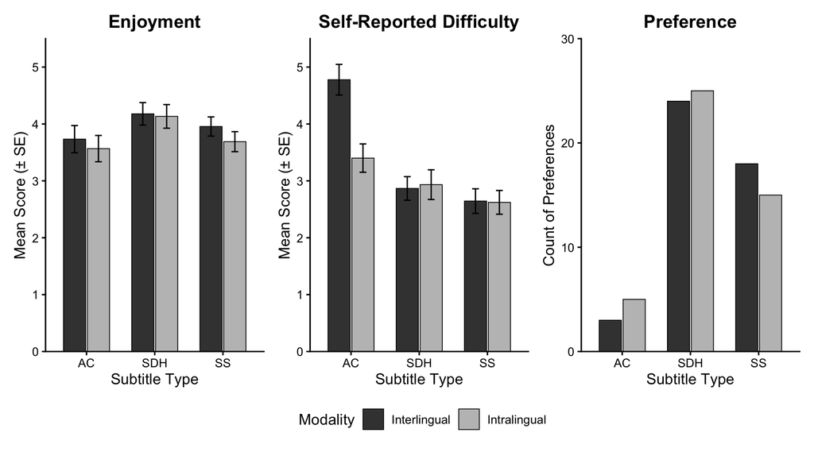

```r
modality_fills <- c("Interlingual" = "grey25", "Intralingual" = "grey75")

diff_enj_summary <- diff_enj %>%
  mutate(
    Subtitle_Type = factor(Subtitle_Type, levels = c("AC", "SDH", "SS")),
    Modality      = factor(Modality, levels = c("Interlingual", "Intralingual"))
  ) %>%
  group_by(Metric, Subtitle_Type, Modality) %>%
  summarise(M  = mean(Score, na.rm = TRUE),
            SE = sd(Score, na.rm = TRUE) / sqrt(n()),
            .groups = "drop")

p_enj <- ggplot(
    diff_enj_summary %>% filter(Metric == "Enjoyment"),
    aes(x = Subtitle_Type, y = M, fill = Modality)) +
  geom_bar(stat = "identity", position = position_dodge(0.7),
           width = 0.65, colour = "black", linewidth = 0.3) +
  geom_errorbar(aes(ymin = M - SE, ymax = M + SE),
                position = position_dodge(0.7), width = 0.2, linewidth = 0.5) +
  scale_fill_manual(values = modality_fills) +
  scale_y_continuous(limits = c(0, 5.5), breaks = 0:5, expand = c(0,0)) +
  labs(title = "Enjoyment", x = "Subtitle Type",
       y = "Mean Score (\u00b1 SE)", fill = "Modality") +
  theme_classic(base_size = 12) +
  theme(plot.title = element_text(face = "bold", hjust = 0.5),
        legend.position = "none")

p_diff <- ggplot(
    diff_enj_summary %>% filter(Metric == "Self_Reported_Difficulty"),
    aes(x = Subtitle_Type, y = M, fill = Modality)) +
  geom_bar(stat = "identity", position = position_dodge(0.7),
           width = 0.65, colour = "black", linewidth = 0.3) +
  geom_errorbar(aes(ymin = M - SE, ymax = M + SE),
                position = position_dodge(0.7), width = 0.2, linewidth = 0.5) +
  scale_fill_manual(values = modality_fills) +
  scale_y_continuous(limits = c(0, 5.5), breaks = 0:5, expand = c(0,0)) +
  labs(title = "Self-Reported Difficulty", x = "Subtitle Type",
       y = "Mean Score (\u00b1 SE)", fill = "Modality") +
  theme_classic(base_size = 12) +
  theme(plot.title = element_text(face = "bold", hjust = 0.5),
        legend.position = "none")

pref_summary <- pref_data %>%
  mutate(Preference = factor(Preference, levels = c("AC", "SDH", "SS")),
         Modality   = factor(Modality, levels = c("Interlingual", "Intralingual"))) %>%
  count(Modality, Preference)

p_pref <- ggplot(pref_summary,
                 aes(x = Preference, y = n, fill = Modality)) +
  geom_bar(stat = "identity", position = position_dodge(0.7),
           width = 0.65, colour = "black", linewidth = 0.3) +
  scale_fill_manual(values = modality_fills) +
  scale_y_continuous(limits = c(0, 30), breaks = seq(0,30,10), expand = c(0,0)) +
  labs(title = "Preference", x = "Subtitle Type",
       y = "Count of Preferences", fill = "Modality") +
  theme_classic(base_size = 12) +
  theme(plot.title = element_text(face = "bold", hjust = 0.5),
        legend.position = "none")

combined_q <- (p_enj + p_diff + p_pref) +
  plot_layout(guides = "collect") &
  theme(legend.position = "bottom")

print(combined_q)
```

# 7. Correlation Analysis

## 7.1 Repeated-Measures Correlations

```r
questionnaire_clean <- questionnaire_raw %>%
  filter(TOI %in% c("ENJ", "ENJ-1", "ENJ1", "ENJ-2", "ENJ2",
                    "SD",  "SD-1",  "SD1")) %>%
  mutate(
    Last_key_press = as.numeric(Last_key_press),
    # Reverse score SD: high score = difficult
    Last_key_press = if_else(
      str_detect(TOI, "SD"),
      8 - Last_key_press,
      Last_key_press
    ),
    Metric = case_when(
      str_detect(TOI, "ENJ") ~ "Enjoyment",
      str_detect(TOI, "SD")  ~ "Self_Reported_Difficulty",
      TRUE ~ NA_character_
    ),
    Participant = as.factor(Participant)
  ) %>%
  mutate(
    Participant_num = as.integer(str_extract(as.character(Participant), "\\d+"))
  ) %>%
  filter(!Participant_num %in% exclude_ids) %>%
  select(-Participant_num) %>%
  filter(!is.na(Metric)) %>%
  group_by(Participant, Media, Metric) %>%
  summarise(Score = mean(Last_key_press, na.rm = TRUE), .groups = "drop") %>%
  pivot_wider(names_from = Metric, values_from = Score)

merged_data <- left_join(
  data_sub,
  questionnaire_clean,
  by = c("Participant", "Media")
)

cat("Merged data rows:", nrow(merged_data), "\n")
```

```
## Merged data rows: 270
```

```r
cat("Missing Enjoyment:", sum(is.na(merged_data$Enjoyment)), "\n")
```

```
## Missing Enjoyment: 0
```

```r
cat("Missing Difficulty:", sum(is.na(merged_data$Self_Reported_Difficulty)), "\n")
```

```
## Missing Difficulty: 0
```

```r
subjective_measures <- c("Self_Reported_Difficulty", "Enjoyment")

results_rmcorr <- data.frame()

for (mod in c("Intralingual", "Interlingual")) {

  d <- merged_data %>%
    filter(Modality == mod) %>%
    as.data.frame()

  for (eye_m in eye_tracking_measures) {
    for (subj_m in subjective_measures) {

      d_temp          <- d
      d_temp$eye_var  <- d[[eye_m]]
      d_temp$subj_var <- d[[subj_m]]
      d_clean         <- d_temp[!is.na(d_temp$eye_var) &
                                !is.na(d_temp$subj_var), ]

      tryCatch({
        rc <- rmcorr(
          participant = Participant,
          measure1    = eye_var,
          measure2    = subj_var,
          dataset     = d_clean
        )

        results_rmcorr <- rbind(results_rmcorr, data.frame(
          Modality    = mod,
          Eye_Metric  = eye_m,
          Subj_Metric = subj_m,
          r           = round(rc$r, 3),
          CI_lower    = round(rc$CI[1], 3),
          CI_upper    = round(rc$CI[2], 3),
          p_raw       = round(rc$p, 4),
          df          = rc$df
        ))
      }, error = function(e) NULL)
    }
  }
}

results_rmcorr <- results_rmcorr %>%
  mutate(
    p_adj = round(p.adjust(p_raw, method = "BH"), 4),
    sig   = case_when(
      p_adj < .001 ~ "***",
      p_adj < .01  ~ "**",
      p_adj < .05  ~ "*",
      p_adj < .10  ~ ".",
      TRUE         ~ ""
    )
  ) %>%
  arrange(Subj_Metric, Modality, Eye_Metric)

write.csv(results_rmcorr, 'data/rmcorr_results.csv', row.names = FALSE)

cat("Total comparisons:", nrow(results_rmcorr), "\n")
```

```
## Total comparisons: 16
```

```r
cat("Significant after BH correction (p_adj < .05):",
    sum(results_rmcorr$p_adj < .05), "\n\n")
```

```
## Significant after BH correction (p_adj < .05): 2
```

```r
kable(results_rmcorr,
      caption = "Repeated-Measures Correlations with BH Correction")
```

Repeated-Measures Correlations with BH Correction

| Modality | Eye_Metric | Subj_Metric | r | CI_lower | CI_upper | p_raw | df | p_adj | sig |
| --- | --- | --- | --- | --- | --- | --- | --- | --- | --- |
| Interlingual | Mean_fixation_duration | Enjoyment | -0.101 | -0.301 | 0.107 | 0.3413 | 89 | 0.9033 |  |
| Interlingual | Number_of_fixations | Enjoyment | -0.067 | -0.269 | 0.141 | 0.5291 | 89 | 0.9668 |  |
| Interlingual | Prop_reading_time | Enjoyment | -0.050 | -0.253 | 0.158 | 0.6410 | 89 | 0.9668 |  |
| Interlingual | Pupil_pct | Enjoyment | -0.090 | -0.291 | 0.118 | 0.3952 | 89 | 0.9033 |  |
| Intralingual | Mean_fixation_duration | Enjoyment | -0.025 | -0.230 | 0.182 | 0.8152 | 89 | 0.9668 |  |
| Intralingual | Number_of_fixations | Enjoyment | 0.018 | -0.188 | 0.224 | 0.8620 | 89 | 0.9668 |  |
| Intralingual | Prop_reading_time | Enjoyment | 0.025 | -0.182 | 0.230 | 0.8137 | 89 | 0.9668 |  |
| Intralingual | Pupil_pct | Enjoyment | 0.004 | -0.202 | 0.210 | 0.9668 | 89 | 0.9668 |  |
| Interlingual | Mean_fixation_duration | Self_Reported_Difficulty | 0.092 | -0.116 | 0.293 | 0.3836 | 89 | 0.9033 |  |
| Interlingual | Number_of_fixations | Self_Reported_Difficulty | 0.515 | 0.346 | 0.652 | 0.0000 | 89 | 0.0000 | *** |
| Interlingual | Prop_reading_time | Self_Reported_Difficulty | 0.475 | 0.298 | 0.620 | 0.0000 | 89 | 0.0000 | *** |
| Interlingual | Pupil_pct | Self_Reported_Difficulty | 0.141 | -0.067 | 0.337 | 0.1833 | 89 | 0.7332 |  |
| Intralingual | Mean_fixation_duration | Self_Reported_Difficulty | -0.062 | -0.265 | 0.145 | 0.5563 | 89 | 0.9668 |  |
| Intralingual | Number_of_fixations | Self_Reported_Difficulty | 0.012 | -0.194 | 0.217 | 0.9099 | 89 | 0.9668 |  |
| Intralingual | Prop_reading_time | Self_Reported_Difficulty | -0.009 | -0.215 | 0.197 | 0.9313 | 89 | 0.9668 |  |
| Intralingual | Pupil_pct | Self_Reported_Difficulty | -0.185 | -0.376 | 0.022 | 0.0795 | 89 | 0.4240 |  |

## 7.2 Forest Plot

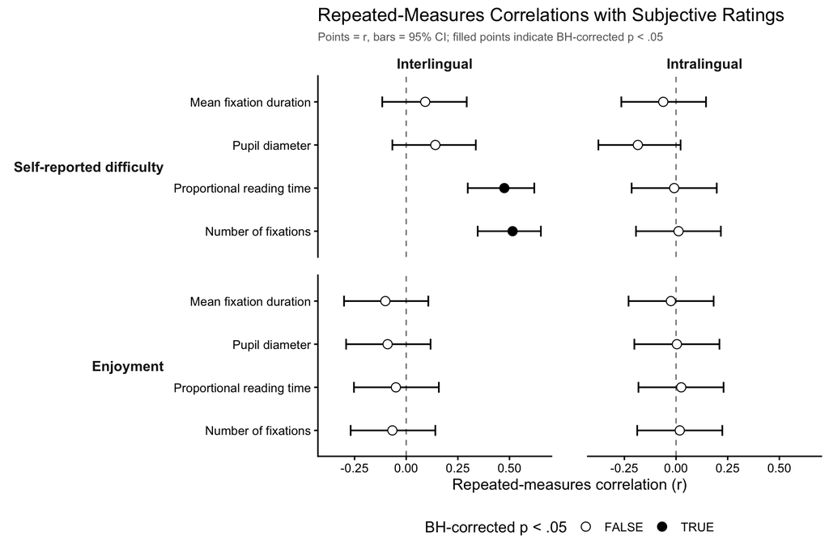

```r
plot_data <- results_rmcorr %>%
  mutate(
    Significant = p_adj < .05,
    Eye_Metric_label = dplyr::recode(Eye_Metric,
      "Number_of_fixations"    = "Number of fixations",
      "Prop_reading_time"      = "Proportional reading time",
      "Mean_fixation_duration" = "Mean fixation duration",
      "Pupil_pct"              = "Pupil diameter"
    ),
    Subj_label = dplyr::recode(Subj_Metric,
      "Self_Reported_Difficulty" = "Self-reported difficulty",
      "Enjoyment"                = "Enjoyment"
    ),
    Eye_Metric_label = factor(Eye_Metric_label,
      levels = c("Number of fixations", "Proportional reading time",
                 "Pupil diameter", "Mean fixation duration")),
    Subj_label = factor(Subj_label, levels = c("Self-reported difficulty", "Enjoyment")),
    Modality   = factor(Modality, levels = c("Interlingual", "Intralingual"))
  )

ggplot(plot_data,
       aes(x = r, y = Eye_Metric_label,
           shape = Significant, fill = Significant)) +
  geom_vline(xintercept = 0, linetype = "dashed",
             colour = "grey50", linewidth = 0.5) +
  geom_errorbarh(aes(xmin = CI_lower, xmax = CI_upper),
                 height = 0.25, linewidth = 0.6, colour = "black") +
  geom_point(size = 3, colour = "black") +
  scale_shape_manual(values = c("FALSE" = 21, "TRUE" = 19),
                     labels = c("FALSE" = "FALSE", "TRUE" = "TRUE"),
                     name   = "BH-corrected p < .05") +
  scale_fill_manual(values = c("FALSE" = "white", "TRUE" = "black"),
                    labels = c("FALSE" = "FALSE", "TRUE" = "TRUE"),
                    name   = "BH-corrected p < .05") +
  facet_grid(Subj_label ~ Modality, scales = "fixed", switch = "y") +
  labs(
    title    = "Repeated-Measures Correlations with Subjective Ratings",
    subtitle = "Points = r, bars = 95% CI; filled points indicate BH-corrected p < .05",
    x        = "Repeated-measures correlation (r)",
    y        = NULL
  ) +
  theme_classic(base_size = 12) +
  theme(
    strip.placement   = "outside",
    strip.background  = element_blank(),
    strip.text.y.left = element_text(angle = 0, hjust = 1,
                                     face = "bold", size = 11),
    strip.text.x      = element_text(face = "bold", size = 11),
    legend.position   = "bottom",
    panel.spacing.x   = unit(1, "cm"),
    panel.spacing.y   = unit(0.5, "cm"),
    plot.subtitle     = element_text(size = 9, colour = "grey40")
  )
```

## 7.3 Comparison: rmcorr with Raw Pupil Diameter

Same 16-comparison family as 7.1, with raw pupil diameter replacing Pupil_pct; BH correction applied across the 16 comparisons.

```r
eye_measures_norm <- c("Mean_fixation_duration", "Number_of_fixations",
                       "Prop_reading_time", "Average_pupil_diameter")
results_rmcorr_norm <- data.frame()

for (mod in c("Intralingual", "Interlingual")) {
  d <- merged_data %>% filter(Modality == mod) %>% as.data.frame()
  for (eye_m in eye_measures_norm) {
    for (subj_m in subjective_measures) {
      d_temp          <- d
      d_temp$eye_var  <- d[[eye_m]]
      d_temp$subj_var <- d[[subj_m]]
      d_clean <- d_temp[!is.na(d_temp$eye_var) & !is.na(d_temp$subj_var), ]
      rc <- rmcorr(participant = Participant, measure1 = eye_var,
                   measure2 = subj_var, dataset = d_clean)
      results_rmcorr_norm <- rbind(results_rmcorr_norm, data.frame(
        Modality = mod, Eye_Metric = eye_m, Subj_Metric = subj_m,
        r = round(rc$r, 3), CI_lower = round(rc$CI[1], 3),
        CI_upper = round(rc$CI[2], 3), p_raw = round(rc$p, 4), df = rc$df))
    }
  }
}

results_rmcorr_norm <- results_rmcorr_norm %>%
  mutate(p_BH = round(p.adjust(p_raw, method = "BH"), 4)) %>%
  arrange(Subj_Metric, Modality, Eye_Metric)

kable(results_rmcorr_norm,
      caption = "rmcorr with raw pupil diameter (BH-corrected)")
```

rmcorr with raw pupil diameter (BH-corrected)

| Modality | Eye_Metric | Subj_Metric | r | CI_lower | CI_upper | p_raw | df | p_BH |
| --- | --- | --- | --- | --- | --- | --- | --- | --- |
| Interlingual | Average_pupil_diameter | Enjoyment | -0.087 | -0.288 | 0.121 | 0.4100 | 89 | 0.9313 |
| Interlingual | Mean_fixation_duration | Enjoyment | -0.101 | -0.301 | 0.107 | 0.3413 | 89 | 0.9313 |
| Interlingual | Number_of_fixations | Enjoyment | -0.067 | -0.269 | 0.141 | 0.5291 | 89 | 0.9313 |
| Interlingual | Prop_reading_time | Enjoyment | -0.050 | -0.253 | 0.158 | 0.6410 | 89 | 0.9313 |
| Intralingual | Average_pupil_diameter | Enjoyment | -0.025 | -0.230 | 0.182 | 0.8128 | 89 | 0.9313 |
| Intralingual | Mean_fixation_duration | Enjoyment | -0.025 | -0.230 | 0.182 | 0.8152 | 89 | 0.9313 |
| Intralingual | Number_of_fixations | Enjoyment | 0.018 | -0.188 | 0.224 | 0.8620 | 89 | 0.9313 |
| Intralingual | Prop_reading_time | Enjoyment | 0.025 | -0.182 | 0.230 | 0.8137 | 89 | 0.9313 |
| Interlingual | Average_pupil_diameter | Self_Reported_Difficulty | 0.103 | -0.105 | 0.302 | 0.3325 | 89 | 0.9313 |
| Interlingual | Mean_fixation_duration | Self_Reported_Difficulty | 0.092 | -0.116 | 0.293 | 0.3836 | 89 | 0.9313 |
| Interlingual | Number_of_fixations | Self_Reported_Difficulty | 0.515 | 0.346 | 0.652 | 0.0000 | 89 | 0.0000 |
| Interlingual | Prop_reading_time | Self_Reported_Difficulty | 0.475 | 0.298 | 0.620 | 0.0000 | 89 | 0.0000 |
| Intralingual | Average_pupil_diameter | Self_Reported_Difficulty | -0.180 | -0.372 | 0.027 | 0.0885 | 89 | 0.4720 |
| Intralingual | Mean_fixation_duration | Self_Reported_Difficulty | -0.062 | -0.265 | 0.145 | 0.5563 | 89 | 0.9313 |
| Intralingual | Number_of_fixations | Self_Reported_Difficulty | 0.012 | -0.194 | 0.217 | 0.9099 | 89 | 0.9313 |
| Intralingual | Prop_reading_time | Self_Reported_Difficulty | -0.009 | -0.215 | 0.197 | 0.9313 | 89 | 0.9313 |